# lab

**Convex and Distributed Optimization Lab**  
**MSIAM — Université Grenoble Alpes — 2019/2020**  
**Lecturers: Jérôme Malick, Yassine Laguel, Sélim Chraibi**

**Author(s): Darche Clément, Chazareix Guillaume**

```python
# Automatic reload of local libraries
%load_ext autoreload
%autoreload 2
%reload_ext autoreload
%matplotlib inline
```

> **I. Introduction**  
> **II. The optimization problem**  
> **III. Implementing the solvers**  
> GD (Gradient descent))  
> SGD (Stochastic Gradient Descent))  
> SAGA (Stochastic Average Gradient "Amélioré"))  
> SVRG (Stochastic Variance Reduced Gradient))  
> Comparison  
> **IV. Regularization**  
> **V. Further development**

In this lab, you will implement optimization algorithms that you've studied in class and use them to fit a logistic regression classification model.

You will be implementing a simplified version of [`sklearn.linear_model.LogisticRegression`](https://scikit-learn.org/stable/modules/generated/sklearn.linear_model.LogisticRegression.html).

Part of the work has already been done for you (see the `\lib` folder), so you'll only have to implement the `##### TODO (i) #####` sections of the code. Whenever you complete such a section, we ask you to **copy it in this notebook**. We want you to **only send us a pdf or html export of this notebook** so we won't be able to see your work if it's not in this notebook.

Report in groups of 1 to 3 students.  
**Due date:** Monday, January 6, 2019 (before midnight).  
**Send to:** cdo.grenoble@gmail.com

# I. Introduction

We consider the [Student Performance](http://archive.ics.uci.edu/ml/datasets/Student+Performance) dataset. This dataset contains student demographic, social, school-related features, how many classes they've missed, etc.

The goal we give ourselves is to predict whether a student will pass (final grade > 12).

We denote $A \in \mathcal{M}_{n,d}(\mathbb{R})$ the feature matrix, containing $n$ samples with $d$ features, and $b \in \{-1,1\}^n$ the label vector where $-1$ encodes `fail` and $1$ encodes `pass`.

The data has already been preprocessed (yay less work for you 🎉). You can check `\lib\datasets.py` if you're curious, otherwise, you can just use the following to load your dataset:

```python
from lib.datasets import load_student_data

A_train, A_test, b_train, b_test = load_student_data('data/student-mat.csv', split=0.25)
```

As mentioned previously, you're going to implement a simplified version of [`sklearn.linear_model.LogisticRegression`](https://scikit-learn.org/stable/modules/generated/sklearn.linear_model.LogisticRegression.html). So let's first see what the finished product should look like.

**Question:**

- Import [sklearn.linear_model.LogisticRegression](https://scikit-learn.org/stable/modules/generated/sklearn.linear_model.LogisticRegression.html) .
- Create an instance of sklearn's logistic regression classifiers with SAGA as its solver.
- Fit the classifier on the training data and compute the score of the fitted model on the test set.

```python
from sklearn.linear_model import LogisticRegression
logreg = LogisticRegression(solver="saga")
logreg.fit(A_train, b_train)
score = logreg.score(A_test, b_test)
print(f"Accuracy on test set: {score}")
```

```
Accuracy on test set: 0.9292929292929293
```

# II. The optimization problem

Logistic regression consists in finding the parameter $x \in \mathbb{R}^d$ that best fits: $$ b_i = \begin{cases} \phantom{-}1 \ \textrm{ if }\ \langle a_{i}, x\rangle \ge 0 \\ -1 \ \textrm{ if }\ \langle a_{i}, x\rangle < 0 \end{cases} $$ for all the samples $i$ of the training set (where $a_i$ is the $i^{th}$ line of $A$ and $b_i$ the $i^{th}$ element of $b$). To measure this fit, logistic regression chooses the following loss:

$$ \textrm{LogisticLoss}(b_i, \left\langle a_{i}, x\right\rangle ) = \log \left(1+\exp \left(-b_{i}\left\langle a_{i}, x\right\rangle\right)\right) $$

The corresponding optimization problem we will consider is the following:

Minimization of the empirical risk $f$ of the $L_2$-regularized logistic regression model, on the dataset $(A_{\textrm{train}},b_{\textrm{train}})$: $$ \begin{aligned} \textrm{min}_{x\in \mathbb{R}^d} \ f(x) \ &= \ \textrm{min}_{x\in \mathbb{R}^d} \ \frac{1}{n_{\textrm{train}}} \sum_{i=1}^{n_{\textrm{train}}} f_i(x) \\ &= \ \textrm{min}_{x\in \mathbb{R}^d}\frac{1}{n_{\textrm{train}}} \sum_{i=1}^{n_{\textrm{train}}} \textrm{LogisticLoss}(b_i, \left\langle a_{i}, x\right\rangle ) + \frac{l_2}{2}\|x\|^{2}_2, \end{aligned} $$ where $l_2 \ge 0$ is the $L_2$ regularization coefficient.

To simplify the notation, we'll stop indexing $A$, $b$ and $n$ with "$\textrm{train}$" in the following.

**Question:** $f$ is $\mu$-strongly convex.

- Give a lower bound on $\mu$.
- Complete **TODO (1)** in **\lib\linear_model.py**.

> **Answer:**

> A lower bound on $\mu$, as f is $\mu$-strongly convex (with LogisticLoss just strictly convex), is:

> \begin{align*} \mu \geq l_2 \end{align*}

> with $l_2 \ge 0$ the $L_2$ regularization coefficient.

**Question:** For any square matrix $M$, denote $\lambda_{\max}(M)$ the largest eighenvalue of $M$.

- Prove that $\lambda_{\max}(\nabla^2 f_i) \le \lambda_{\max}(\frac{a_i a_i^T}{4} + l_2 I_d)$
- Prove that $\lambda_{\max}(a_i a_i^T) \le \|a_i\|^2_2$

> **Answer:**

> We have $a_ia_i^T = \|a_i\|_2^2$. Let's take $x$ such that $a_ia_i^Tx = \lambda x$, $\lambda$ a real. Then :

> \begin{aligned}a_ia_i^Tx = \lambda x &\implies \|a_i\|_2^2x = \lambda x \\ &\implies (\|a_i\|_2^2 - \lambda)x = 0 \\ &\implies \begin{cases} \lambda = \|a_i\|_2^2 \ \textrm { if x } \neq 0 \\ \lambda = 0 \ \textrm{if x = 0} \end{cases} \\ &\implies \lambda_{max}(a_ia_i^T) \leq \|a_i\|_2^2 \end{aligned}

A consequence of these results is that the $f_i$s and $f$ are all $L$-smooth with $L \le \frac{\max_i\|a_i\|^2_2}{4} + l_2$ and we can therefore use the following value in our implementation:

```
L = 0.25 * max(np.linalg.norm(A,2,axis=1))**2 + self.l2
```

# III. Implementing the solvers

To implement gradient methods, we need an oracle that will compute both batch gradients $\nabla f$ and partial gradients $\nabla f_i$.

**Question:** In the code below, $\nabla f$ has already been implemented.

- Complete **TODO (2)** bellow.
- Add your code to **\lib\linear_model.py**.

```
def grad(x, i=None):
    '''
    Gradient of the objective function at x.
    If no i is given, grad should return the batch gradient.
    Otherwise, it should return the partial gradient associated the the datapoint (A[i], b[i]).
    '''

    if i is None: # return batch gradient
        output = -b/(1 + np.exp(b*np.dot(A, x)))
        output = output/n @ A
        output += self.l2*x
    else: # return partial gradient associated the datapoint (A[i], b[i])
        Ai, bi = A[i].reshape(1, -1), b[i]
        output = -bi/(1 + np.exp(bi*np.dot(Ai.reshape(1,-1), x)))
        output = output @ Ai
        output += self.l2*x
    return output
```

# GD (Gradient descent)

At iteration k of the GD algorithm, the following update is executed:

$$ x_{k+1} \leftarrow x_{k} - \gamma\nabla f(x_k) $$

**Question:**

- What stepsize $\gamma$ ensures the convergence of this algorithm and under what assumptions?
- Complete **TODO (3)** and **TODO (4)**
- Add your code to **\lib\solvers.py**.

> **Answer:**

> Assuming that the function is convex, differentiable (which is the case here) and L-smooth, the stepsize \begin{align*} \gamma = \frac{1}{L} \end{align*}

> ensures the convergence of the Gradient Descent algorithm.

```
def GD(x0, grad, max_iter, n, L, mu):
    '''
    Parameters
    ----------
    x0: array, shape (nb_features,)
        Initialisation of the solver
    grad: function
        Gradient of the objective function
    max_iter: int
        Number of iterations (i.e. number of descent steps). Note that for GD or SVRG,
        one iteration is one epoch i.e, one pass through the data, while for SGD, SAG and SAGA,
        one iteration uses only one data point.
    n: int
        Dataset size
    L: float
        Smoothness constant of the objective function
    mu: float
        Strong convexity constant of the objective function

    Returns
    -------
    x: array, shape (nb_features,)
        final iterate of the solver
    x_tab: array, shape (nb_features, max_iter)
        table of all the iterates
    '''
    stepsize  = 1/L
    x         = x0
    x_tab     = np.copy(x)

    for k in range(max_iter):
        x     = x - stepsize*grad(x)
        x_tab = np.vstack((x_tab, x))

    return x, x_tab
```

**Question:** Run the code below to test your code.

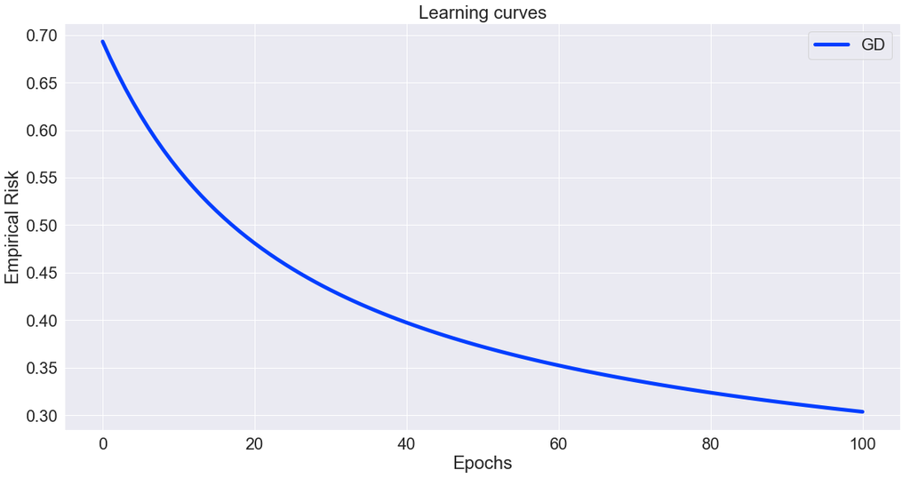

```python
from lib.linear_model import LogisticRegression
from lib.visuals import learning_curve

clf_gd = LogisticRegression(solver='gd', l2=0.01, max_iter=100)
clf_gd.fit(A_train, b_train)

learning_curve(GD=clf_gd)
```

# SGD (Stochastic Gradient Descent)

At iteration k of the SGD algorithm, the following update is executed:

$$ \begin{cases} i \textrm{ chosen randomly in } \{1...n\}\\ x_{k+1} \leftarrow x_{k} - \gamma_k \nabla f_i(x_k) \\ \end{cases} $$

**Question:**

- What stepsize $\gamma_k$ ensures the convergence of this algorithm and under what assumptions?
- Complete **TODO (5)**
- Add your code to **\lib\solvers.py**.

> **Answer:**

> A standard using the SGD algorithm is to take diminishing step-size to ensure convergence. So for this algorithm, we took \begin{align*} \gamma_k = \frac{1}{k+1} \end{align*} under the assumption that f is convex.

```
import random as rd

def SGD(x0, grad, prox, max_iter, n, L, mu):

    x         = x0
    x_tab     = np.copy(x)

    for k in range(max_iter):

        stepsizek = 1/(k+1)
        i = rd.randint(0, n-1)
        x = x - stepsizek*grad(x, i)
        if k%n == 0: # each completed epoch
            x_tab = np.vstack((x_tab, x))

    return x, x_tab
```

**Question:** Run the code below to test your code.

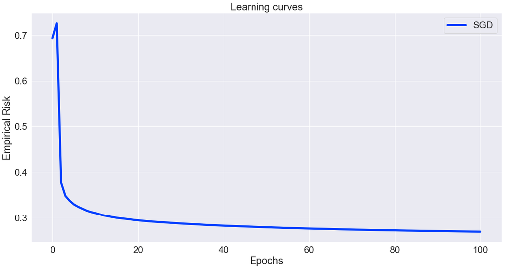

```python
clf_sgd = LogisticRegression(solver='sgd', l2=0.01, max_iter=100*len(b_train))
clf_sgd.fit(A_train, b_train)

learning_curve(SGD=clf_sgd)
```

# SAGA (Stochastic Average Gradient "Amélioré")

SAGA starts by computing a single batch gradient, then at iteration k, the following update is executed:

$$ \begin{cases} i \textrm{ chosen randomly in } \{1...n\}\\ x_{k+1} \leftarrow x_{k} - \gamma_k\big(\nabla f_i(x_k) - \alpha_i + \bar{\alpha}\big) \\ \alpha_i \leftarrow \nabla f_i(x) \end{cases} $$

where $(\alpha_j)_{j=1}^n$ are gradients evaluated at previous iterates and $\bar{\alpha}=\frac{1}{n}\sum^n_{j=1}\alpha_j$.

**Question:**

- What stepsize $\gamma_k$ ensures the convergence of this algorithm and under what assumptions?
- Complete **TODO (6)**
- Add your code to **\lib\solvers.py**.

> **Answer:**

> Assuming that the $f_i$ are L-smooth and that f is stronglyx convex, a constant step-size of value \begin{align*} \gamma_k = \gamma = \frac{1}{2(\mu n + L)} \end{align*}

> ensures convergence for the SAGA algorith.

```
def SAGA(x0, grad, max_iter, n, L, mu):

    x         = x0
    x_tab     = np.copy(x)
    stepsize = 1/(2*(mu*n + L))
    ai = 0
    asum = 0
    ng = 0
    for k in range(max_iter):

        i = rd.randint(0, n-1)
        g = grad(x, i)
        ab = asum / ng if ng != 0 else 0
        x = x - stepsize*(g - ai + ab)
        ai = g
        asum += g
        ng += 1
        if k%n == 0: # each completed epoch
            x_tab = np.vstack((x_tab, x))

    return x, x_tab
```

**Question:** Run the code below to test your code.

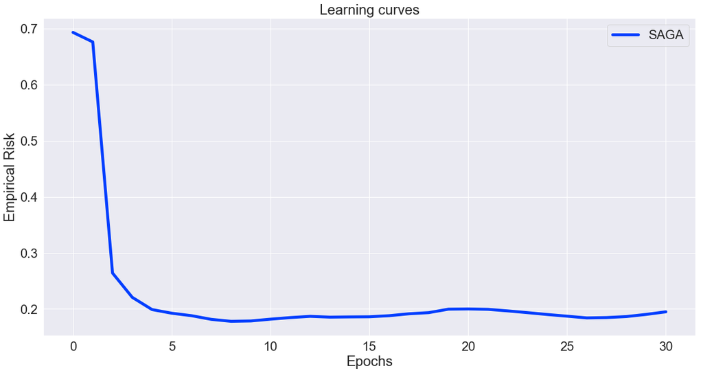

```python
clf_saga = LogisticRegression(solver='saga', l2=0.01, max_iter=30*len(b_train))
clf_saga.fit(A_train, b_train)

learning_curve(SAGA=clf_saga)
```

# SVRG (Stochastic Variance Reduced Gradient)

At iteration k of the SVRG algorithm, we perform the following:

$$ \begin{cases} \textrm{Compute the batch gradient } \nabla f(x_k)\\ \textrm{Initialise }y_0 = x_k\\ \textrm{for m in 0...M-1: } \begin{cases} i \textrm{ chosen randomly in } \{1...n\} \\ y_{m+1} \leftarrow y_{m} - \gamma_k\big(\nabla f_i(y_m) - \nabla f_i(x_k) + \nabla f(x_k)) \end{cases}\\ x_{k+1} \leftarrow y_{M} \end{cases} $$

**Question:**

- What stepsize $\gamma_k$ ensures the convergence of this algorithm and under what assumptions?
- Complete **TODO (7)**
- Add your code to **\lib\solvers.py**.

> **Answer:**

> A result from the course states that, with f convex, any sequence converging toward > 0 whose serie does not converge is a correct value for $\gamma_k$. Experiments showed that the following value is a good one : \begin{aligned} \gamma_k = \frac{1}{(k+1)^{3/4}} \end{aligned}

```
def SVRG(x0, grad, max_iter, n, L, mu, M=10):

    x         = x0
    x_tab     = np.copy(x)

    for k in range(max_iter):

        gf = grad(x)
        ym = x
        stepsize = 1/(k+1)**(3/4)
        for m in range(M):
            i = rd.randint(0,n-1)
            gi = grad(x, i)
            ym = ym - stepsize*(grad(ym, i) - gi + gf)
        x = ym
        x_tab = np.vstack((x_tab, x))

    return x, x_tab
```

**Question:** Run the code below to test your code.

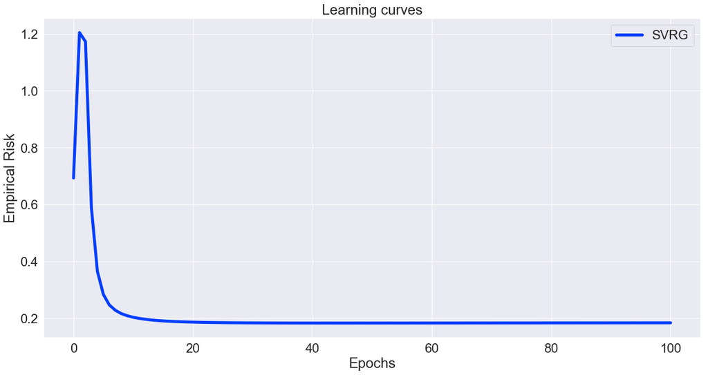

```python
clf_svrg = LogisticRegression(solver='svrg', l2=0.01, max_iter=100)
clf_svrg.fit(A_train, b_train)

learning_curve(SVRG=clf_svrg)
```

# Comparison

**Question:** Run the code below to compare all the methods you've implemented.

```python
epochs = 50
n = len(b_train)

clf_gd   = LogisticRegression(solver='gd', l2=0.01, max_iter=epochs)
clf_sgd  = LogisticRegression(solver='sgd', l2=0.01, max_iter=epochs*n)
clf_saga = LogisticRegression(solver='saga', l2=0.01, max_iter=epochs*n)
clf_svrg = LogisticRegression(solver='svrg', l2=0.01, max_iter=epochs)

clf_gd.fit(A_train, b_train)
clf_sgd.fit(A_train, b_train)
clf_saga.fit(A_train, b_train)
clf_svrg.fit(A_train, b_train)
```

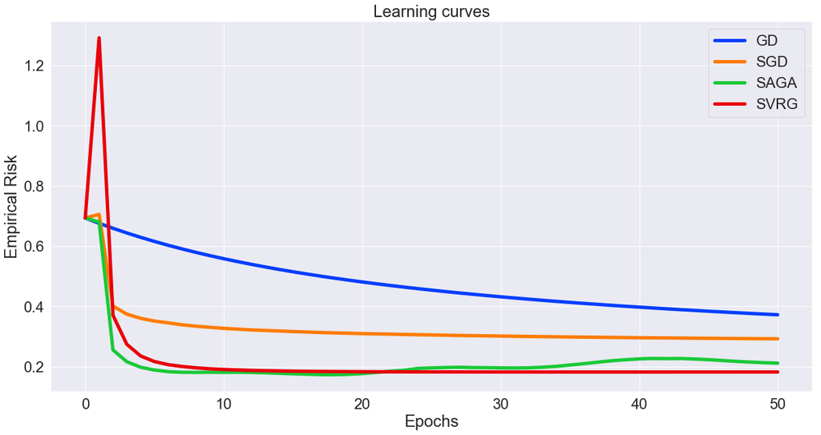

```
gd:	Accuracy on training set: 88.9%
	Accuracy on testing set:  89.9%
sgd:	Accuracy on training set: 87.2%
	Accuracy on testing set:  85.9%
saga:	Accuracy on training set: 92.6%
	Accuracy on testing set:  90.9%
svrg:	Accuracy on training set: 94.9%
	Accuracy on testing set:  91.9%
```

```python
learning_curve(GD=clf_gd, SGD=clf_sgd, SAGA=clf_saga, SVRG=clf_svrg)

for clf, name in zip([clf_gd, clf_sgd, clf_saga, clf_svrg], ['gd', 'sgd', 'saga', 'svrg']):
    print(name + ':' \
          + "\tAccuracy on training set: {0:0.1f}%".format(100*clf.score(A_train, b_train)))
    print("\tAccuracy on testing set:  {0:0.1f}%".format(100*clf.score(A_test, b_test)))
```

# IV. Regularization

**Question:**

- Rewrite the empirical risk minimization objective with both $L_1$ and $L_2$ regularization (with coefficients $l_1$ and $l_2$).
- Is this objective $\mu$-strongly convex, $L$-smooth, differentiable?
- Complete the **TODO (8)** to account for the new term in the objective.
- Add your code to **lib/linear_model.py**.

> **Answer:** The empirical risk minimization objective with both $L_1$ and $L_2$ regularization is : \begin{aligned} \textrm{min}_{x\in \mathbb{R}^d} \ f(x) &= \ \textrm{min}_{x\in \mathbb{R}^d}\frac{1}{n_{\textrm{train}}} \sum_{i=1}^{n_{\textrm{train}}} \textrm{LogisticLoss}(b_i, \left\langle a_{i}, x\right\rangle ) + \frac{l_2}{2}\|x\|^{2}_2 + l_1|x| \end{aligned}

> This objective is not differentiable due to the presence of the $L_1$ norm. It is only stricly convex since none of its composite is strongly convex.

```
self._empirical_risk = lambda x: sum(self._logistic_loss(A, b, x))/n \
                                 + self.l2/2.0 * np.linalg.norm(x,2) \
                                 + self.l1 * np.linalg.norm(x,1)
```

The minimization algorithms we've implemented have a slow rate of convergence for this new objective function. We will therefore use *proximal* variations of these algorithms.

**Question:** Using the $\textrm{prox}_{l_1 \|\cdot\|_1}$ operator, write down the $k^{th}$ step of proximal GD, proximal SGD, proximal SAGA, and proximal SVRG.

> **Answer:**

> The $k^{th}$ step of each algorithm using the proximal operator does > not change by much:

> **For GD :** $$ x_{k+1} \leftarrow \textrm{prox}_{\gamma l_1 \|\cdot\|_1}(x_{k} - \gamma\nabla f(x_k)) $$ **For SGD :** $$ \begin{cases} i \textrm{ chosen randomly in } \{1...n\}\\ x_{k+1} \leftarrow \textrm{prox}_{ \gamma_k l_1 \|\cdot\|_1}(x_{k} - \gamma_k \nabla f_i(x_k)) \\ \end{cases} $$ **For SAGA :** $$ \begin{cases} i \textrm{ chosen randomly in } \{1...n\}\\ x_{k+1} \leftarrow \textrm{prox}_{\gamma_k l_1 \|\cdot\|_1}(x_{k} - \gamma_k\big(\nabla f_i(x_k) - \alpha_i + \bar{\alpha}\big)) \\ \alpha_i \leftarrow \nabla f_i(x) \end{cases} $$

> **For SVRG :** $$ \begin{cases} \textrm{Compute the batch gradient } \nabla f(x_k)\\ \textrm{Initialise }y_0 = x_k\\ \textrm{for m in 0...M-1: } \begin{cases} i \textrm{ chosen randomly in } \{1...n\} \\ y_{m+1} \leftarrow \textrm{prox}_{\gamma_k l_1 \|\cdot\|_1}(y_{m} - \gamma_k\big(\nabla f_i(y_m) - \nabla f_i(x_k) + \nabla f(x_k))) \end{cases}\\ x_{k+1} \leftarrow y_{M} \end{cases} $$

**Question:**

- Give a closed-form expression of $\textrm{prox}_{l_1 \|\cdot\|_1}$
- Complete **TODO (9)** (note that you can access the $l_1$ coefficient using **self.l1**).
- Add your code to **\lib\linear_model.py**.

> **Answer:**

> By definition, we have : \begin{aligned} prox_{l_1 \|\cdot\|_1}(x) &= argmin_y (l_1 \|y\|_1 + \frac{1}{2}\|y - x\|_2^2) \\ &= argmin_y ( l_1 \sum_i |y_i| + \frac{1}{2} \sum_i (y_i - x_i)^2 )\\ &= argmin_y \sum_i(l_1 |y_i| + \frac{1}{2} (y_i - x_i)^2)\\ &= \{prox_{l_1 \|\cdot\|_1}(x)_i\}_i \end{aligned}

> with $prox_{l_1 \|\cdot\|_1}(x)_i$ = $ argmin_{y_i} (l_1 |y_i| +\frac{1}{2} (y_i - x_i)^2)$

> Then, if $y_i > 0$, the derivative is ($y_i - x_i + l_1)$ so $y_i = x_i - l_1$ if $x_i > l_1$. Similarly, if $y_i < 0$, $y_i = l_1 + x_i$ if $x_i < -l_1$. So :

> \begin{aligned} prox_{l_1 \|\cdot\|_1}(x) &= \{sgn(x_i)max(|x_i| - l_1, 0)\}_i \end{aligned}

```
def prox(x, stepsize):
    return np.sign(x)*np.maximum(np.abs(x) - stepsize*self.l1, 0)
```

**Question:**

- Add **prox** to the attributes of the solvers (both in the call to **self.solver** in **/lib/linear_model.py** and in **/lib/solvers.py**) as follows:  
  solver(x0, grad, **prox**, self.max_iter, n, L, mu)
- Add a proximal step to all the algorithms in **/lib/solvers.py**.
- Paste one of these algorithms in the cell bellow.

```
def SGD(x0, grad, prox, max_iter, n, L, mu):

    x         = x0
    x_tab     = np.copy(x)

    for k in range(max_iter):
        stepsizek = 1/(k+1)
        i = rd.randint(0, n-1)
        x = prox(x - stepsizek*grad(x, i), stepsizek)
        if k%n == 0: # each completed epoch
            x_tab = np.vstack((x_tab, x))

    return x, x_tab
```

**Question:** If your proximal gradient descent is correctly implemented, the following cell will plot the support of the solution for various values of $l_1$.

- Interpret the plot and explain what can $L_1$ regularization be used for.

> **Answer:**

> In the plot we can observe that when $l_1$ gets bigger, there are more coordinates of x that take the value 0. We can assume that it is the smallest coefficients that are removed (i.e set to 0). In that case, the $L_1$ regularization can be used to simplify our model by removing the smallest (and less usefull) components.

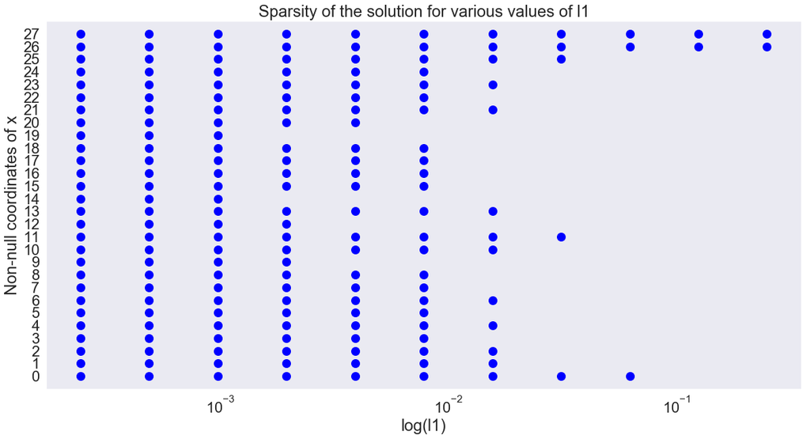

```python
from lib.visuals import l1_regularization_plot

clf = lambda l1: LogisticRegression(solver='gd', l1=l1, l2=0.1, max_iter=1000)

l1_regularization_plot(clf, A_train, b_train)
```

**Question:** The following cell will plot the value of the coordinates of the solution for various values of $l_2$.

- Interpret the plot and explain what can $L_2$ regularization be used for.

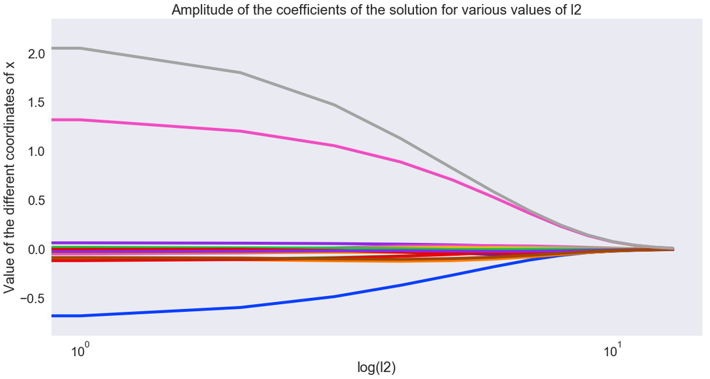

```python
from lib.visuals import l2_regularization_plot

clf = lambda l2: LogisticRegression(solver='gd', l1=0.01, l2=l2, max_iter=1000)

l2_regularization_plot(clf, A_train, b_train)
```

# V. Further development

We expect that you go beyond the lab's questions and that you develop certain aspects of your work, depending on your personal interests and skills, for instance:

- Implementations and numerical tests (further developments, more experiments, etc.)
- Applications in learning or statistics (interpretation of some results, other models, other datasets, etc.)
- Theoretical or mathematical questions (convergence proofs, convergence rates, advanced versions of an algorithm, theoretical analysis of special cases, etc.)

**Keyword ideas**: standard or stochastic Newton method, ADMM, continuation methods, tests on large scale datasets, intuition behind variance reduction, catalyst...

Here we implement the SAGA optimizer for Torch

```python
from torch.optim.optimizer import Optimizer, required
from torch import zeros
import copy

class SAGA(Optimizer):
    """Implementation of SAGA optimizer
    """

    def __init__(self, params, lr=required):
        defaults = dict(lr=lr)
        super(SAGA, self).__init__(params, defaults)
        self.state["iteration"] = 0

    def __setstate__(self, state):
        super(SAGA, self).__setstate__(state)

    def step(self, closure=None):
        """ Performs a single optimization step.
        Arguments:
            closure (callable, optional): A closure that reevaluates the model
                and returns the loss.
        """
        loss = None
        if closure is not None:
            loss = closure()


        for group in self.param_groups:
            for p in group['params']:
                if p.grad is None:
                    continue
                d_p = p.grad.data
                param_state = self.state[p]
                if 'gradient_sum' not in param_state:
                    param_state['gradient_sum'] = d_p.data.clone()
                    gs = torch.zeros_like(d_p)
                else:
                    ngs = param_state['gradient_sum']
                    gs =  ngs.data.clone()
                    ngs.add_(d_p.data)

                if 'last_gradient' not in param_state:
                    lg = torch.zeros_like(d_p)
                else:
                    lg = param_state['last_gradient']
                param_state['last_gradient'] = d_p.data.clone()

                p.data.add_(-group['lr']*d_p)
                p.data.add_(-group['lr']/(self.state["iteration"]+1)*gs)
                p.data.add_(+group['lr']*lg)

        self.state["iteration"] += 1

        return loss
```

Here, we take a simple model that we train on MNIST dataset

```python
from torchvision import datasets, transforms
import torch
import torch.nn as nn
import torch.nn.functional as F

USE_CUDA = True
BATCH_SIZE = 256
kwargs = {'num_workers': 1, 'pin_memory': True} if USE_CUDA else {}
device = torch.device("cuda" if USE_CUDA else "cpu")
train_loader = torch.utils.data.DataLoader(
    datasets.MNIST('./data', train=True, download=True,
                   transform=transforms.Compose([
                       transforms.ToTensor(),
                       transforms.Normalize((0.1307,), (0.3081,))
                   ])),
    batch_size=BATCH_SIZE, shuffle=True, **kwargs)

test_loader = torch.utils.data.DataLoader(
    datasets.MNIST('./data', train=False, transform=transforms.Compose([
                       transforms.ToTensor(),
                       transforms.Normalize((0.1307,), (0.3081,))
                   ])),
    batch_size=BATCH_SIZE, shuffle=True, **kwargs)


class Neural_Network(nn.Module):
    def __init__(self):
        super(Neural_Network, self).__init__()
        self.conv1 = nn.Conv2d(1, 32, 3, 1)
        self.conv2 = nn.Conv2d(32, 64, 3, 1)
        self.dropout1 = nn.Dropout2d(0.25)
        self.dropout2 = nn.Dropout2d(0.5)
        self.fc1 = nn.Linear(9216, 128)
        self.fc2 = nn.Linear(128, 10)

    def forward(self, x):
        x = self.conv1(x)
        x = F.relu(x)
        x = self.conv2(x)
        x = F.max_pool2d(x, 2)
        x = self.dropout1(x)
        x = torch.flatten(x, 1)
        x = self.fc1(x)
        x = F.relu(x)
        x = self.dropout2(x)
        x = self.fc2(x)
        output = F.log_softmax(x, dim=1)
        return output

# The following code is for training neural networks

model = Neural_Network().to(device)
model.train()

# we are using stochastic gradient descent optimizer
optimizer = SAGA(model.parameters(), lr=0.01)

# we train the neural networks for 1000 epochs.
# epochs basically means the number of time the whole set of data will pass through the neural network.
def train(model, device, train_loader, optimizer, epoch):
    for batch_idx, (data, target) in enumerate(train_loader):
        data, target = data.to(device), target.to(device)
        optimizer.zero_grad()
        output = model(data)
        loss = F.nll_loss(output, target)
        loss.backward()
        optimizer.step()
        if batch_idx % 100 == 0:
            print('Train Epoch: {} [{}/{} ({:.0f}%)]\tLoss: {:.6f}'.format(
                epoch, batch_idx * len(data), len(train_loader.dataset),
                100. * batch_idx / len(train_loader), loss.item()))

def test(model, device, test_loader):
    model.eval()
    test_loss = 0
    correct = 0
    with torch.no_grad():
        for data, target in test_loader:
            data, target = data.to(device), target.to(device)
            output = model(data)
            test_loss += F.nll_loss(output, target, reduction='sum').item()  # sum up batch loss
            pred = output.argmax(dim=1, keepdim=True)  # get the index of the max log-probability
            correct += pred.eq(target.view_as(pred)).sum().item()

    test_loss /= len(test_loader.dataset)

    print('\nTest set: Average loss: {:.4f}, Accuracy: {}/{} ({:.0f}%)\n'.format(
        test_loss, correct, len(test_loader.dataset),
        100. * correct / len(test_loader.dataset)))

NUM_EPOCHS = 15
for epoch in range(NUM_EPOCHS):
    print(f"#--- EPOCH {epoch} - TRAIN")
    train(model, device, train_loader, optimizer, epoch)
    print(f"#--- EPOCH {epoch} - TEST")
    test(model, device, test_loader)
```

```
#--- EPOCH 0 - TRAIN
Train Epoch: 0 [0/60000 (0%)]	Loss: 2.317374
Train Epoch: 0 [25600/60000 (43%)]	Loss: 1.062804
Train Epoch: 0 [51200/60000 (85%)]	Loss: 0.723718
#--- EPOCH 0 - TEST

Test set: Average loss: 0.4266, Accuracy: 8759/10000 (88%)

#--- EPOCH 1 - TRAIN
Train Epoch: 1 [0/60000 (0%)]	Loss: 0.369790
Train Epoch: 1 [25600/60000 (43%)]	Loss: 0.452761
Train Epoch: 1 [51200/60000 (85%)]	Loss: 0.244839
#--- EPOCH 1 - TEST

Test set: Average loss: 0.3336, Accuracy: 9008/10000 (90%)

#--- EPOCH 2 - TRAIN
Train Epoch: 2 [0/60000 (0%)]	Loss: 0.352164
Train Epoch: 2 [25600/60000 (43%)]	Loss: 0.279642
Train Epoch: 2 [51200/60000 (85%)]	Loss: 0.217881
#--- EPOCH 2 - TEST

Test set: Average loss: 0.2704, Accuracy: 9214/10000 (92%)

#--- EPOCH 3 - TRAIN
Train Epoch: 3 [0/60000 (0%)]	Loss: 0.434523
Train Epoch: 3 [25600/60000 (43%)]	Loss: 0.221417
Train Epoch: 3 [51200/60000 (85%)]	Loss: 0.304230
#--- EPOCH 3 - TEST

Test set: Average loss: 0.2360, Accuracy: 9311/10000 (93%)

#--- EPOCH 4 - TRAIN
Train Epoch: 4 [0/60000 (0%)]	Loss: 0.328628
Train Epoch: 4 [25600/60000 (43%)]	Loss: 0.231943
Train Epoch: 4 [51200/60000 (85%)]	Loss: 0.192341
#--- EPOCH 4 - TEST

Test set: Average loss: 0.2066, Accuracy: 9382/10000 (94%)

```

[output cut: 64 more lines]

```
#--- EPOCH 13 - TRAIN
Train Epoch: 13 [0/60000 (0%)]	Loss: 0.224651
Train Epoch: 13 [25600/60000 (43%)]	Loss: 0.137995
Train Epoch: 13 [51200/60000 (85%)]	Loss: 0.144239
#--- EPOCH 13 - TEST

Test set: Average loss: 0.1226, Accuracy: 9612/10000 (96%)

#--- EPOCH 14 - TRAIN
Train Epoch: 14 [0/60000 (0%)]	Loss: 0.088415
Train Epoch: 14 [25600/60000 (43%)]	Loss: 0.179681
Train Epoch: 14 [51200/60000 (85%)]	Loss: 0.115522
#--- EPOCH 14 - TEST

Test set: Average loss: 0.1197, Accuracy: 9609/10000 (96%)
```

Trained with the SAGA optimizer, we obtain a satisfying result with an accuracy above 90% (96% after 15 epochs).